# Final

The quarterback is the most important position in all of sports. As the game of football becomes increasingly pass heavy, this fact becomes more and more true year in and year out. In fact, between the 32 NFL teams in 2022, there is currently \$3,084,928,180 invested in quarterbacks (NFL active player contracts.). This number will only rise as the rookie quarterbacks drafted in 2022 sign their contracts. Furthermore, it recently became rumored that Tom Brady will sign a \$375 million contract to go into broadcasting once his NFL career is done. That is, because of his impact on the field as a quarterback, Brady will be paid nearly $40 million a year to work roughly 6 hours a day, just 3 days a week, for about half of the weeks in a year.

That being said, with great finance comes great responsibility. Quarterbacks, as well as the teams and management staffs that select them in the draft are constantly judged for their decisions. If a general manager and coach use a highly valued draft pick on a quarterback who does not pan out, the careers of all three will be over in a heartbeat. Take the Cleveland Browns for example. Since 2000, They have had 31 quarterbacks start for them (Wikimedia Foundation. (2022, April 25). List of Cleveland Browns starting quarterbacks.). In that same time period, they have had 10 head coaches (Organization), and 11 general managers (Cleveland Browns. The Pittsburgh steelers, on the other hand, have had just 11 quarterbacks start for them in that timeframe (Wikimedia Foundation. (2022, May 4). List of Pittsburgh Steelers starting quarterbacks.). As a result of the stability, they have had just 2 coaches (Pittsburgh) and 1 general manager (Wikimedia Foundation. (2022, May 9). Kevin Colbert.) since 2000.

As you may imagine, the connection between quarterback success and job security often causes franticness amongst the coaches and general managers who are uncertain in their starting quarterback’s abilities. As a result, many people, including general managers, coaches, analysts, commentators, fans, and even quarterbacks themselves, have tried to answer the age old question: “How do you draft a good quarterback?”

Many theories have arisen in response to this question. In this analysis, I will take a look at a few different claims in regard to drafting a quarter back, analyze their validity, and attempt to predict the future success of some of the leagues best and brightest young quarterback talent.

Theory 1: “If I was running a team, here’s my rule for the GM: There are only 2 spots where you’re allowed to draft a quarterback. In the top 10, or [in the] 6th round or later.” – Nick Wright, What’s Wright? With Nick Wright (Wright)

Theory 2: “Fast QBs lead to more success” – Everyone on Twitter in regard to Malik Willis, Lamar Jackson, etc.

Theory 3: “Short QBs will struggle to win” – Claim made yearly about shorter quarterbacks such as Baker Mayfield, Kyler Murray, Drew Brees, etc.

Theory 4: “If you're going to put all of your eggs in one quarterback's basket – and nowadays, you don't have much of a choice – then you might have to be willing to make some schematic changes in order to support him.” – Brad Gagnon, Bleacher Report (Gagnon)

Theory 5: (In regard to spending extra draft capital on offense in order to improve a young quarterbacks play) “My goal in this draft is to make Daniel Jones successful. If that means that Garrett Wilson is my wide receiver 4, that’s gonna help him be successful.” – Brett Kollmann, (Kollmann), (21:52)

The first step in testing these theories is getting the data we need. I will be using the nfl_data_py library to supply all of my data. More information on the data can be found here: https://pypi.org/project/nfl-data-py/. Special thanks should be given to [Ben Baldwin](https://twitter.com/benbbaldwin), [Sebastian Carl](https://twitter.com/mrcaseb), [Lee Sharpe](https://twitter.com/LeeSharpeNFL), [Tan Ho](https://twitter.com/_TanHo), and Josh Kazan for their work on the data set and making it public.

```python
pip install nfl_data_py
```

Following this, I imported all of the other libraries I need.

```python
#Import libraries
import sqlite3
import pandas as pd
import matplotlib.pyplot as plt
import matplotlib.colors as mcolors
import numpy as np
import nfl_data_py as nfl
from collections import Counter
```

Next, I gather my data. Drafts will import all of the draft picks that will be needed for this project. Starts will hold the depth charts for each team for each game since 2001. Combine will hold the combine results for every player 2003-2020. The winners and losers lists simply hold the names of every quarterback to win a Super Bowl and lose a Super Bowl, respectively.

The table schemas are as follows:

- draft(season, team, round, pick, pfr_id, pfr_name, player_id, side, category, position)
- starts(season week, team, season_type, position, depth_chart_position formation, depth_team, jersey_number, full_name, first_name, last_name, gsis_id)
- combine(name, college, height, weight, vert, broad, bench, shuttle, cone, 10yd, 20yd, 40yd, season, position)
- winners(player_name)
- losers(player_name)

```python
#Importing data
draft = nfl.import_draft_picks()
starts = nfl.import_depth_charts()
combine = nfl.import_combine_data()
winners = ["Trent Dilfer", "Tom Brady", "Brad Johnson", "Tom Brady", "Tom Brady", "Ben Roethlisberger", "Peyton Manning", "Eli Manning", "Ben Roethlisberger", "Drew Brees", "Aaron Rodgers", "Eli Manning", "Joe Flacco", "Russell Wilson", "Tom Brady", "Peyton Manning", "Tom Brady", "Nick Foles", "Tom Brady", "Patrick Mahomes", "Tom Brady", "Matthew Stafford"]
losers = ["Kerry Collins", "Kurt Warner", "Rich Gannon", "Jake Delhomme", "Donovan McNabb", "Matt Hasselbeck", "Rex Grossman", "Tom Brady", "Kurt Warner", "Peyton Manning", "Ben Roethlisberger", "Tom Brady", "Colin Kaepernick", "Peyton Manning", "Russell Wilson", "Cam Newton", "Matt Ryan", "Tom Brady", "Jared Goff", "Jimmy Garoppolo", "Patrick Mahomes", "Joe Burrow"]
```

3 NFL teams have changed their location since 2000, changing their teams abbreviation. These abbreviations are made uniform by franchise with the code below.

```python
#Correcting team abbrevition changes
draft.loc[draft['team'] == 'STL', 'team'] = 'LAR'
starts.loc[starts['team'] == 'STL', 'team'] = 'LAR'
draft.loc[draft['team'] == 'LA', 'team'] = 'LAR'
starts.loc[starts['team'] == 'LA', 'team'] = 'LAR'
draft.loc[draft['team'] == 'OAK', 'team'] = 'LV'
starts.loc[starts['team'] == 'OAK', 'team'] = 'LV'
draft.loc[draft['team'] == 'SD', 'team'] = 'LAC'
starts.loc[starts['team'] == 'SD', 'team'] = 'LAC'
```

Focussing on just the more recent data (2000 - present), a database stroing just the quarterbacks drafted since 2000 is created.

```python
#Filtering draft data
draft.drop(columns = ['player_id'], inplace = True)
draft = draft[draft['season'] >= 2000]
QBs = draft[draft['position'] == 'QB']
```

The combine data needs to be filtered to just quarterbacks as well.

```python
#Filtering combine data
combine = combine[combine['position'] == 'QB']
```

Now the same is done with the starts data, making a copy with all the positions (instead of just the QBs) for later use. Furthermore, filtering by depth_team == 1, we can store just the starters for each game.

```python
#Filtering starts data
starts = starts[starts['season'] >= 2000]
starts = starts[starts['depth_team'] == 1]
starts.drop(starts[starts['depth_chart_position'] == 'KR'].index, inplace = True)
starts.drop(starts[starts['depth_chart_position'] == 'PR'].index, inplace = True)
all_pos_starts = starts.copy()
starts = starts[starts['depth_chart_position'] == 'QB']
```

Using the newly filtered data, preparation is made for a new colum, tallying the starts each player had for the team which drafted them.

```python
#Calculating player starts
starts = starts.groupby(['team', 'full_name']).count()
starts.drop(starts.loc[:, 'week':'gsis_id'].columns, axis = 1, inplace = True)
starts.columns = ['team_starts']
starts['team'] = [t[0] for t in starts.index.values]
starts['pfr_name'] = [t[1] for t in starts.index.values]
```

Another field is added to the data, containing the total starts for a player over their career.

```python
#Adding a team_starts_total column, to get the total starts for a player
starts = starts.join(starts.groupby('pfr_name')['team_starts'].sum(), on = 'pfr_name', rsuffix = '_total')
```

Repeat this process for all the non QBs as well.

```python
#Calculating player starts
all_pos_starts = all_pos_starts.groupby(['team', 'full_name']).count()
all_pos_starts.drop(all_pos_starts.loc[:, 'week':'gsis_id'].columns, axis = 1, inplace = True)
all_pos_starts.columns = ['team_starts']
all_pos_starts['team'] = [t[0] for t in all_pos_starts.index.values]
all_pos_starts['pfr_name'] = [t[1] for t in all_pos_starts.index.values]
```

Repeat this process for all the non QBs as well.

```python
#Adding a team_starts_total column, to get the total starts for a player
all_pos_starts = all_pos_starts.join(all_pos_starts.groupby('pfr_name')['team_starts'].sum(), on = 'pfr_name', rsuffix = '_total')
```

Merge the databases to create 2 mega databases.

```python
#Create main dataframes, df and draft_total
df = QBs.merge(starts.reset_index(drop=True), how = 'left', on = ['team', 'pfr_name'])
draft_total = draft.merge(all_pos_starts.reset_index(drop=True), how = 'left', on = ['team', 'pfr_name'])
```

Change NAN values to 0, when applicable.

```python
#Fill in missing values where applicable
df['team_starts'] = df['team_starts'].fillna(0)
df['team_starts_total'] = df['team_starts_total'].fillna(0)
draft_total['team_starts'] = draft_total['team_starts'].fillna(0)
draft_total['team_starts_total'] = draft_total['team_starts_total'].fillna(0)
```

Using the winners and losers lists, add a count to each player on how many Super Bowls they won, and how many they appeared in.

```python
#Add Super Bowl winners and appearances to df
d = dict()
for x in winners:
  if x not in d:
    d[x] = 1
  else:
    d[x] += 1

df['sb_wins'] = df['pfr_name'].map(d)
df['sb_wins'] = df['sb_wins'].fillna(0)

d = dict()
for x in losers:
  if x not in d:
    d[x] = 1
  else:
    d[x] += 1

df['sb'] = df['pfr_name'].map(d)
df['sb'] = df['sb'].fillna(0)
df['sb'] = df['sb'] + df['sb_wins']
```

Add the combine numbers to the data frame and drop the unnecessary columns.

```python
#Add combine data, drop unnecessary
combine.rename(columns = {'name':'pfr_name'}, inplace = True)
df = df.merge(combine, how='left', on='pfr_name')
df.rename(columns = {'season_x':'season'}, inplace = True)
df.drop(['college', 'weight', 'vert', 'broad', 'bench', 'shuttle', 'cone', '10yd', '20yd', 'season_y', 'position_y', 'position_x'], axis = 1, inplace = True)
```

The combine database was missing data from 2000-2002 and 2021-2022, so the missing data was added for important figures. I also removed Dwayne Haskins, as his tragic passing means we will never witness his full potential.

```python
#Add missing combine data, remove Haskins
df.loc[df['pfr_name'] == 'Tom Brady', 'height'] = 76.4
df.loc[df['pfr_name'] == 'Tom Brady', '40yd'] = 5.3
df.loc[df['pfr_name'] == 'Drew Brees', 'height'] = 72.3
df.loc[df['pfr_name'] == 'Drew Brees', '40yd'] = 4.85
df.loc[df['pfr_name'] == 'Kenny Pickett', 'height'] = 75.25
df.loc[df['pfr_name'] == 'Kenny Pickett', '40yd'] = 4.73
df.loc[df['pfr_name'] == 'Trevor Lawrence', 'height'] = 77.63
df.loc[df['pfr_name'] == 'Zach Wilson', 'height'] = 74.13
df.loc[df['pfr_name'] == 'Trey Lance', 'height'] = 75.55
df.loc[df['pfr_name'] == 'Justin Fields', 'height'] = 74.75
df.loc[df['pfr_name'] == 'Justin Fields', '40yd'] = 4.46
df.loc[df['pfr_name'] == 'Matt Corral', 'height'] = 73.63
df.loc[df['pfr_name'] == 'Sam Howell', 'height'] = 72.63
df.loc[df['pfr_name'] == 'Desmond Ridder', 'height'] = 75.38
df.loc[df['pfr_name'] == 'Desmond Ridder', '40yd'] = 4.52
df.loc[df['pfr_name'] == 'Malik Willis', 'height'] = 72.5
df.loc[df['pfr_name'] == 'Kellen Mond', 'height'] = 74.63
df.loc[df['pfr_name'] == 'Kellen Mond', '40yd'] = 4.62
df.loc[df['pfr_name'] == 'Kyle Trask', 'height'] = 77.25
df.loc[df['pfr_name'] == 'Kyle Trask', '40yd'] = 5.08
df.loc[df['pfr_name'] == 'Eli Manning', '40yd'] = 4.90
df.loc[df['pfr_name'] == 'Eli Manning', 'team_starts_total'] = 234
df.loc[df['pfr_name'] == 'Ben Roethlisberger', '40yd'] = 4.75
df.loc[df['pfr_name'] == 'Matthew Stafford', '40yd'] = 4.81
df.drop(df.index[df['pfr_name'] == 'Dwayne Haskins'], inplace = True)
```

5 smaller databases are created for graphing.

```python
#Create 5 sub databases to be used in graphing
sb_winners = df[df['sb_wins'] > 0]
sb_contenders = df[df['sb'] > 0]
young_qbs = df[(df['season'] >= 2018) & (df['round'] <= 3)]
df_old = df[df['season'] < 2018]
draft_total_old = draft_total[draft_total['season'] < 2018]
```

Kickers and punters are removed from the data set due to their unique positions. Chris Jones and Steve Smith are also removed as their common names cause unwanted data ovelap, and non of the players involved are all that important to the data.

```python
#Remove unwanted data
draft_total_old.drop(draft_total_old[draft_total_old['position'] == 'K'].index, inplace = True)
draft_total_old.drop(draft_total_old[draft_total_old['position'] == 'P'].index, inplace = True)
draft_total_old.drop(draft_total_old[draft_total_old['pfr_name'] == 'Chris Jones'].index, inplace = True)
draft_total_old.drop(draft_total_old[draft_total_old['pfr_name'] == 'Steve Smith'].index, inplace = True)
```

Drew Brees and Eli Manning are dropped from the winners list, because the teams that they were drafted by are not the teasm that they would win with, making them rare exceptions. Nick Foles is dropped because his Super Bowl was won as a back up quarterback, meaning the team around him was built for another players playing style.

```python
#Fixing up our last bit of data
winner_draft = draft[draft['pfr_name'].isin(winners)]
winner_draft.drop(winner_draft[winner_draft['pfr_name'] == 'Drew Brees'].index, inplace = True)
winner_draft.drop(winner_draft[winner_draft['pfr_name'] == 'Nick Foles'].index, inplace = True)
winner_draft.drop(winner_draft[winner_draft['pfr_name'] == 'Eli Manning'].index, inplace = True)
```

Here, a data base containing all the players that were drafted within 4 years prior to the Super Bowl winning player having been drafted and by the same team. This include the players that were part of his draft class.

```python
#Creating a players drafted before database for plotting
temp = [draft[(r['season']  - 4 < draft['season']) &
              (draft['season'] <= r['season']) &
              (draft['team'] == r['team'])] for i, r in winner_draft.iterrows()]
all_before = pd.concat(temp, ignore_index=True)
before_count = Counter(all_before['position'])
```

Here, a data base containing all the players that were drafted within 4 years after to the Super Bowl winning player having been drafted and by the same team.

```python
#Creating a players drafted after database for plotting
temp = [draft[(r['season'] < draft['season']) &
              (draft['season'] <= r['season'] + 4) &
              (draft['team'] == r['team'])] for i, r in winner_draft.iterrows()]
all_after = pd.concat(temp, ignore_index=True)
after_count = Counter(all_after['position'])
```

Major draft capital (first 3 rounds) is then seperated from minor draft capital (last 4 rounds).

```python
#Seperating major capital from minor capital
all_before123 = all_before[all_before['round'] <= 3]
before_count123 = Counter(all_before123['position'])

all_before4567 = all_before[all_before['round'] > 3]
before_count4567 = Counter(all_before4567['position'])

all_after123 = all_after[all_after['round'] <= 3]
after_count123 = Counter(all_after123['position'])

all_after4567 = all_after[all_after['round'] > 3]
after_count4567 = Counter(all_after4567['position'])
```

In preparation for plotting, the positions are then ordered in a common NFL nomencalture.

```python
#Preparing for plotting
pos = ['QB', 'RB', 'WR', 'TE', 'T', 'G', 'C', 'DE', 'DT', 'LB', 'DB', 'K', 'P']
before_vals = [before_count[p] for p in pos]
after_vals = [after_count[p] for p in pos]
before_vals123 = [before_count123[p] for p in pos]
after_vals123 = [after_count123[p] for p in pos]
before_vals4567 = [before_count4567[p] for p in pos]
after_vals4567 = [after_count4567[p] for p in pos]
```

**CHART 1a**

The following graph shows the number of starts by quarterback for the team in which they were drafted (y-axis) vs with what pick they were selected (x-axis). The red line represents the line of best fit. The black line represents the number of starts needed to play out an entire rookie contract. First round picks are signed to 5 years deals, and have to start 80 games to meet this requirement. All other players are signed to 4 year deals, and need to start 64 games in order to start an entire rookie deal. Players who land above this line represent players who were resigned to a subsequent contract, ie., successful picks. Players selected after pick 10, who started 100 or more games for the team they were drafted by are labeled. Players are colored according to the round they were selected, with first rounders in the darkest shade of blue, and suller shades for the later round picks.

Certain players, such as Tom Brady, Russell Wilson, Ben Roethlisberger, and Aaron Rodgers, stand out as huge steals for their respective franchises. These players were picked far too late for their production. Expect Dak Prescott to join such ranks in due time, as he will be entering the 2022 season at just age 29, making him the youngest labeled quarterback.

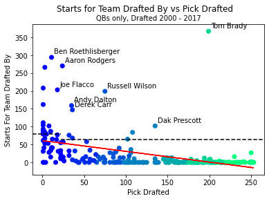

```python
#Charting the amount of starts for by QBs who have played long enough (Team they were drafted by)
plt.scatter(df_old['pick'], df_old['team_starts'], c = df_old['round'], cmap = 'winter')
x = np.polyfit(df_old["pick"], df_old["team_starts"], 1)
p = np.poly1d(x)
plt.plot(df_old["pick"], p(df_old["pick"]),"r--")
plt.suptitle("Starts for Team Drafted By vs Pick Drafted")
plt.title("QBs only, Drafted 2000 - 2017", fontsize = 10)
plt.xlabel("Pick Drafted")
plt.ylabel("Starts For Team Drafted By")
plt.axhline(y = 80, xmin = 0, xmax = 0.12307692307, color = 'k', linestyle = '--')
plt.axhline(y = 64, xmin = 0.12307692307, xmax = 1, color = 'k', linestyle = '--')
outliers = df_old[(df_old['team_starts'] > 100) & (df_old['pick'] > 10)]
for i, r in outliers.iterrows():
  plt.annotate(r['pfr_name'], (r['pick'] + 3, r['team_starts'] + 10))
plt.show()
```

**CHART 1b**

Certain players, such as Tom Brady, Drew Brees, and Ryan Fitzpatrick, each who offered tremendous value for hteir draft slot. Despite this, of the three, only Tom Brady had most of his success for the team that drafted him.

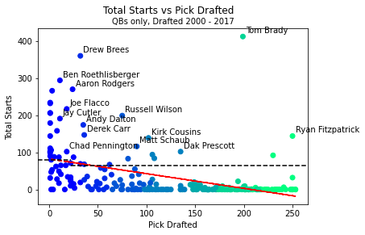

```python
#Charting the amount of starts by QBs who have played long enough (All starts)
plt.scatter(df_old['pick'], df_old['team_starts_total'], c = df_old['round'], cmap = 'winter')
x = np.polyfit(df_old["pick"], df_old["team_starts_total"], 1)
p = np.poly1d(x)
plt.plot(df_old["pick"], p(df_old["pick"]),"r--")
plt.suptitle("Total Starts vs Pick Drafted")
plt.title("QBs only, Drafted 2000 - 2017", fontsize = 10)
plt.xlabel("Pick Drafted")
plt.ylabel("Total Starts")
plt.axhline(y = 80, xmin = 0, xmax = 0.12307692307, color = 'k', linestyle = '--')
plt.axhline(y = 64, xmin = 0.12307692307, xmax = 1, color = 'k', linestyle = '--')
outliers = df_old[(df_old['team_starts_total'] > 100) & (df_old['pick'] > 10)]
for i, r in outliers.iterrows():
  plt.annotate(r['pfr_name'], (r['pick'] + 3, r['team_starts_total'] + 10))
plt.show()
```

**CHART 2a**

The following graph shows the number of starts by player for the team in which they were drafted (y-axis) vs with what pick they were selected (x-axis). The red line represents the line of best fit. The black line represents the number of starts needed to play out an entire rookie contract. First round picks are signed to 5 years deals, and have to start 80 games to meet this requirement. All other players are signed to 4 year deals, and need to start 64 games in order to start an entire rookie deal. Players who land above this line represent players who were resigned to a subsequent contract, ie., successful picks. Players selected after pick 10, who started 250 or more games for the team they were drafted by are labeled. Players are colored according to the round they were selected, with first rounders in the darkest shade of blue, and suller shades for the later round picks.

Certain players, such as Tom Brady, Zak DeOssie, and Jason Witten, stand out as huge steals for their respective franchises. These players were picked far too late for their production. While neither were a quarter back, the position of focus for this project, DeOssie had an amazing 13 year career as the New York Giant long snapper, while Witten quickly became one of the league's best tight ends in Dallas.

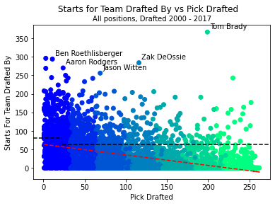

```python
#Charting the amount of starts by players who have played long enough (Team they were drafted by)
plt.scatter(draft_total_old['pick'], draft_total_old['team_starts'], c = draft_total_old['round'], cmap = 'winter')
x = np.polyfit(draft_total_old["pick"], draft_total_old["team_starts"], 1)
p = np.poly1d(x)
plt.plot(draft_total_old["pick"], p(draft_total_old["pick"]),"r--")
plt.suptitle("Starts for Team Drafted By vs Pick Drafted")
plt.title("All positions, Drafted 2000 - 2017", fontsize = 10)
plt.xlabel("Pick Drafted")
plt.ylabel("Starts For Team Drafted By")
plt.axhline(y = 80, xmin = 0, xmax = 0.12307692307, color = 'k', linestyle = '--')
plt.axhline(y = 64, xmin = 0.12307692307, xmax = 1, color = 'k', linestyle = '--')
outliers = draft_total_old[(draft_total_old['team_starts'] > 250) & (draft_total_old['pick'] > 10)]
for i, r in outliers.iterrows():
  plt.annotate(r['pfr_name'], (r['pick'] + 3, r['team_starts'] + 10))
plt.show()
```

**CHART 2b**

Certain players, such as Tom Brady, Drew Brees, and Andrew Whitworth, stand out as huge steals for their respective franchises. These players were picked far too late for their production. Whitworth held down the left tackle position (arguabley the second most important spot behind quraterback) in Cincinati for over a decade before swapping jerseys and doing the same job in Los Angeles for another 5 years.

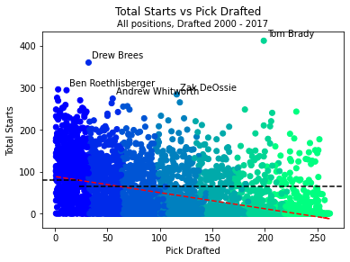

```python
#Charting the amount of starts by players who have played long enough (All starts)
plt.scatter(draft_total_old['pick'], draft_total_old['team_starts_total'], c = draft_total_old['round'], cmap = 'winter')
x = np.polyfit(draft_total_old["pick"], draft_total_old["team_starts_total"], 1)
p = np.poly1d(x)
plt.plot(draft_total_old["pick"], p(draft_total_old["pick"]),"r--")
plt.suptitle("Total Starts vs Pick Drafted")
plt.title("All positions, Drafted 2000 - 2017", fontsize = 10)
plt.xlabel("Pick Drafted")
plt.ylabel("Total Starts")
plt.axhline(y = 80, xmin = 0, xmax = 0.12307692307, color = 'k', linestyle = '--')
plt.axhline(y = 64, xmin = 0.12307692307, xmax = 1, color = 'k', linestyle = '--')
outliers = draft_total_old[(draft_total_old['team_starts_total'] > 270) & (draft_total_old['pick'] > 10)]
for i, r in outliers.iterrows():
  plt.annotate(r['pfr_name'], (r['pick'] + 3, r['team_starts_total'] + 10))
plt.show()
```

In all four of the above graphs, it is worth noting that when comparing the line of best fit to the black lines of success, the average nfl draft pick does not totally pay off for the team in which they were selected. THat beign said, the average first and secind roundpick will get an oppertuniy elsewhere often enough to put players picked in these positions above the black line.

Furthermore, it is also worth noting that in both cases, number of starts for the draft team and total starts regardless of team, the average quarerback starts less games than the average player per draft slot. This confirms the belife that the quarterback position is harder to drafts properly.

**CHART 3a**

The following shows the draft positions of quarterbacks who won Super Bowls (x-axis) and the number of Super Bowls they won (y-axis). The points are colored based on round drafted, where first round picks are in red, and later round picks are in progressivly lessening colors. Players picked after pick 10 and with at least one Super Bowl win are marked with an asterisk (*).

It is worth noting that 6 of these players are selected in the first round, while 4 were selected in later rounds. Furthermore, 7 of the 10 were selected after pick 10.

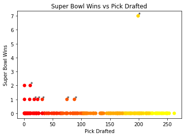

```python
#Super Bowl wins by pick drafted
plt.scatter(df['pick'], df['sb_wins'], c = df['round'], cmap = 'autumn')
plt.title("Super Bowl Wins vs Pick Drafted")
plt.xlabel("Pick Drafted")
plt.ylabel("Super Bowl Wins")
outliers = df[(df['pick'] > 10) & (df['sb_wins'] > 0)]
for i, r in outliers.iterrows():
  plt.annotate('*', (r['pick'], r['sb_wins']))
plt.show()
```

**CHART 3b**

The following shows the draft positions of quarterbacks who appeared in Super Bowls (x-axis) and the number of Super Bowls they appeared in (y-axis). The points are colored based on round drafted, where first round picks are in red, and later round picks are in progressivly lessening colors. Players picked after pick 10 and with at least one Super Bowl appearance are marked with an asterisk (*).

It is worth noting that about half of these players are selected in the first round, while about half were selected in later rounds. Furthermore,10 were selected after pick 10.

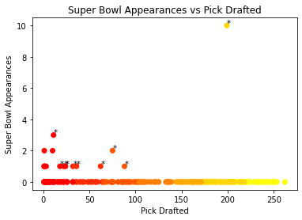

```python
#Super Bowl appearances by pick drafted
plt.scatter(df['pick'], df['sb'], c = df['round'], cmap = 'autumn')
plt.title("Super Bowl Appearances vs Pick Drafted")
plt.xlabel("Pick Drafted")
plt.ylabel("Super Bowl Appearances")
outliers = df[(df['pick'] > 10) & (df['sb'] > 0)]
for i, r in outliers.iterrows():
  plt.annotate('*', (r['pick'], r['sb']))
plt.show()
```

**CHART 4a**

The following chart shows the 40 yard dash time (x-axis) of Super Bowl winning quarterbacks. The points are colored according to speed, with the fastest quarterbacks in green, and slowest in yellow. The black dotted vertical line repreesents the average 40 yard dash time of NFL quarterbacks, a 4.93.

It is incredibly interesting that most of the quarterbacks here are faster than average, but only slightly so. This is likely helped them because they were able to use their speed along side their arm, and not instead of their arm like we see some of the fastest quarterbacks do today.

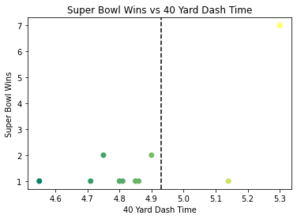

```python
#40 yard dash time by Super Bowl winners
plt.scatter(sb_winners['40yd'], sb_winners['sb_wins'], c = sb_winners['40yd'], cmap = 'summer')
plt.axvline(x = 4.93, color = 'k', label = 'Average QB 40 Time (4.93 sec)', linestyle = '--')
plt.title("Super Bowl Wins vs 40 Yard Dash Time")
plt.ylabel("Super Bowl Wins")
plt.xlabel("40 Yard Dash Time")
plt.show()
```

**CHART 4b**

The following chart shows the 40 yard dash time (x-axis) of Super Bowl appearing quarterbacks. The points are colored according to speed, with the fastest quarterbacks in green, and slowest in yellow. The black dotted vertical line repreesents the average 40 yard dash time of NFL quarterbacks, a 4.93.

Just as above, most of the quarterbacks here are faster than average, but only slightly so. This is likely helped them because they were able to use their speed along side their arm, and not instead of their arm like we see some of the fastest quarterbacks do today.

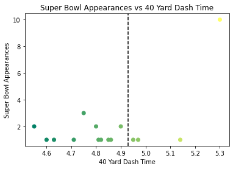

```python
#40 yard dash time by Super Bowl appearances
plt.scatter(sb_contenders['40yd'], sb_contenders['sb'], c = sb_contenders['40yd'], cmap = 'summer')
plt.axvline(x = 4.93, color = 'k', label = 'Average QB 40 Time (4.93 sec)', linestyle = '--')
plt.title("Super Bowl Appearances vs 40 Yard Dash Time")
plt.ylabel("Super Bowl Appearances")
plt.xlabel("40 Yard Dash Time")
plt.show()
```

**CHART 5a**

The following chart shows the height (x-axis) of Super Bowl winning quarterbacks. The points are colored according to height, with the smallest quarterbacks in green, and the tallest in yellow. The black dotted vertical line repreesents the average height of NFL quarterbacks, 75 inches.

Unlike the speed charts above, the Super Bowl winning quarterbacks are pretty evenly spread amongst this chart. In fact, half these guys are on the left, and half are on the right.

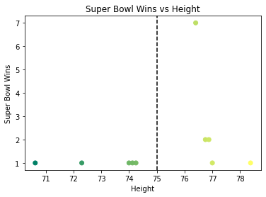

```python
#Height by Super Bowl winners
plt.scatter(sb_winners['height'], sb_winners['sb_wins'], c = sb_winners['height'], cmap = 'summer')
plt.axvline(x = 75, color = 'k', label = 'Average Height (75 in)', linestyle = '--')
plt.title("Super Bowl Wins vs Height")
plt.ylabel("Super Bowl Wins")
plt.xlabel("Height")
plt.show()
```

**CHART 5b**

The following chart shows the height (x-axis) of Super Bowl appearing quarterbacks. The points are colored according to height, with the smallest quarterbacks in green, and the tallest in yellow. The black dotted vertical line repreesents the average height of NFL quarterbacks, 75 inches.

Unlike the speed charts above, the Super Bowl winning quarterbacks are pretty evenly spread amongst this chart. In fact, 2/5 of the quarterbacks are on the left, and 3/5 on the right, gving us a decently even chart that slightly favors height.

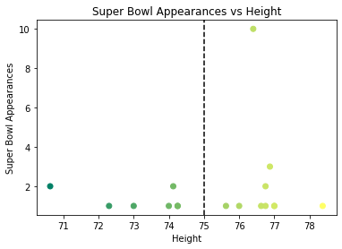

```python
#Height by Super Bowl appearances
plt.scatter(sb_contenders['height'], sb_contenders['sb'], c = sb_contenders['height'], cmap = 'summer')
plt.axvline(x = 75, color = 'k', label = 'Average Height (75 in)', linestyle = '--')
plt.title("Super Bowl Appearances vs Height")
plt.ylabel("Super Bowl Appearances")
plt.xlabel("Height")
plt.show()
```

**CHART 6a**

The following graph charts the positions that draft value was spent on prior to a Super Bowl QB getting picked. For example, for Ben Roethlisberger, a Super Bowl winning quarterback drafted in 2004 by PIT, this graph charts the positions drafted by PIT in the years 2001 - 2004. This is done for every Super Bowl winning quarterback, and each position is summed.

Some intersesting notes here are as follows:

- Two defensive positions lead the way
- Few offensive skill positions (RB, WR, TE) were picked, meaning that the previous QB likely did not have a ton of young talent to work with.

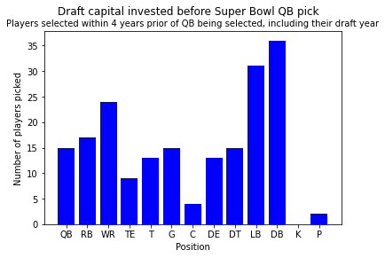

```python
#Players drafted before
plt.bar(range(len(before_vals)), before_vals, label = before_vals, color = 'b')
plt.xticks(range(len(before_vals)), pos)
plt.suptitle("Draft capital invested before Super Bowl QB pick")
plt.title("Players selected within 4 years prior of QB being selected, including their draft year", fontsize = 10)
plt.ylabel("Number of players picked")
plt.xlabel("Position")
plt.show()
```

**CHART 6b**

Some intersesting notes here are as follows:

- WR, an offensive skill position, now leads the way as being the most drafted position.
- Tackles (T) are picked far more often to protect the young quarterbacks.
- Many more offensive skill positions (RB, WR, TE) were picked, giving the new QB lots of talent to work around.

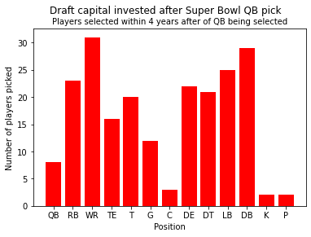

```python
#Players drafted after
plt.bar(range(len(after_vals)), after_vals, label = after_vals, color = 'r')
plt.xticks(range(len(after_vals)), pos)
plt.suptitle("Draft capital invested after Super Bowl QB pick")
plt.title("Players selected within 4 years after of QB being selected", fontsize = 10)
plt.ylabel("Number of players picked")
plt.xlabel("Position")
plt.show()
```

**CHART 7a**

This graph charts the postitions picked before a Super Bowl QB via major draft capital (picked in rounds 1-3). These players are the ones who are expected to contribute majorly and immediately.

This charts trends are very similar to the other blue bar chart above.

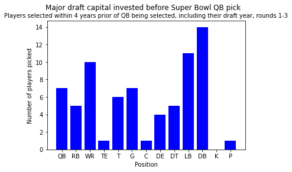

```python
#Players drafted before (Major Capital)
plt.bar(range(len(before_vals123)), before_vals123, label = before_vals123, color = 'b')
plt.xticks(range(len(before_vals123)), pos)
plt.suptitle("Major draft capital invested before Super Bowl QB pick")
plt.title("Players selected within 4 years prior of QB being selected, including their draft year, rounds 1-3", fontsize = 10)
plt.ylabel("Number of players picked")
plt.xlabel("Position")
plt.show()
```

**CHART 7b**

This graph charts the postitions picked after a Super Bowl QB via major draft capital (picked in rounds 1-3). These players are the ones who are expected to contribute majorly and immediately.

One interesting note that differs from chart 6b is that only one other quarterback was selected with a major pick follwoing the drafting of our successful quarterbacks. This makes sense and frees up draft capital for these teams to boost the talent around their new quarterbacks.

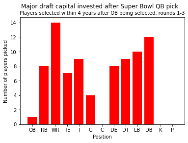

```python
#Players drafted after (Major Capital)
plt.bar(range(len(after_vals123)), after_vals123, label = after_vals123, color = 'r')
plt.xticks(range(len(after_vals123)), pos)
plt.suptitle("Major draft capital invested after Super Bowl QB pick")
plt.title("Players selected within 4 years after QB being selected, rounds 1-3", fontsize = 10)
plt.ylabel("Number of players picked")
plt.xlabel("Position")
plt.show()
```

**CHART 8a**

This graph charts the postitions picked before a Super Bowl QB via minor draft capital (picked in rounds 4-7). These players are the ones who are expected to contribute minorly or not ar all. That being said, players who do play well after being picked in these rounds offer the greatest value.

One interesting note that here in comparison to chart 7a is that many of these teams are swinging the bat on low round quarterbacks before they spend major draft capital on the later.

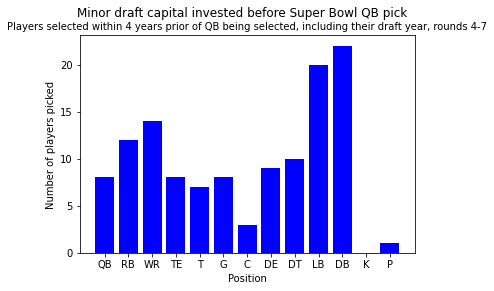

```python
#Players drafted before (Minor Capital)
plt.bar(range(len(before_vals4567)), before_vals4567, label = before_vals4567, color = 'b')
plt.xticks(range(len(before_vals4567)), pos)
plt.suptitle("Minor draft capital invested before Super Bowl QB pick")
plt.title("Players selected within 4 years prior of QB being selected, including their draft year, rounds 4-7", fontsize = 10)
plt.ylabel("Number of players picked")
plt.xlabel("Position")
plt.show()
```

**CHART 8b**

This graph charts the postitions picked after a Super Bowl QB via minor draft capital (picked in rounds 4-7). These players are the ones who are expected to contribute minorly or not ar all. That being said, players who do play well after being picked in these rounds offer the greatest value.

One interesting note that here is that 7 quarterbacks were picked in late rounds after a Super Bowl winning quarterback was picked. This is likely teams trying to solidify their back up at the position incase their great young quarterback gets hurt.

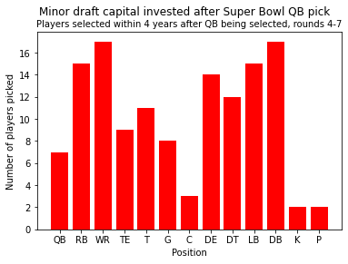

```python
#Players drafted after (Minor Capital)
plt.bar(range(len(after_vals4567)), after_vals4567, label = after_vals4567, color = 'r')
plt.xticks(range(len(after_vals4567)), pos)
plt.suptitle("Minor draft capital invested after Super Bowl QB pick")
plt.title("Players selected within 4 years after QB being selected, rounds 4-7", fontsize = 10)
plt.ylabel("Number of players picked")
plt.xlabel("Position")
plt.show()
```

Now that we have all of our data mapped out, let's take a look back at the hypothesies.

- Theory 1: “If I was running a team, here’s my rule for the GM: There are only 2 spots where you’re allowed to draft a quarterback. In the top 10, or [in the] 6th round or later.” – Nick Wright, What’s Wright? With Nick Wright (Wright)
- Theory 2: “Fast QBs lead to more success” – Everyone on Twitter in regard to Malik Willis, Lamar Jackson, etc.
- Theory 3: “Short QBs will struggle to win” – Claim made yearly about shorter quarterbacks such as Baker Mayfield, Kyler Murray, Drew Brees, etc.
- Theory 4: “If you're going to put all of your eggs in one quarterback's basket – and nowadays, you don't have much of a choice – then you might have to be willing to make some schematic changes in order to support him.” – Brad Gagnon, Bleacher Report (Gagnon)
- Theory 5: (In regard to spending extra draft capital on offense in order to improve a young quarterbacks play) “My goal in this draft is to make Daniel Jones successful. If that means that Garrett Wilson is my wide receiver 4, that’s gonna help him be successful.” – Brett Kollmann, (Kollmann), (21:52)

Looking at charts 1a, 1b, 3a, and 3b, we can reject Theory 1. While there are great quarterbacks selected in the top 10, and in the 6th round or later, Wright's theory totally discounts all the great quarterbacks picked in between.That being said, the hottest areas for good quarterbacks appear to be in the 1st round and on to the early 2nd.

We can then accept Theory 2. While it may not be necessary to have a quarterback as fast as Lamar Jackson or Malike Willis (who's 40 yd times are estimated at 4.34 and 4.40 respectively), charts 4a and 4b show that it certainly does help to have a faster-than-average quarterback at the helm.

Theory 3 can be rejected. Chart 5a shows an even number of quarterbacks in regard to being over or under the average height for the position amongst those who won the Super Bowl. Chart 5b shows a nearly even split amongst quarterbacks who appeared in a superbowl

Theory 4 can be accepted. The final 6 charts show a major change in draft capital investment after drafting a franchise quarterback in an attempt to boost the offense around them.

Finally, in a similar manner to Theory 4, Theory 5 can also be accepted.

For some extra analysis, we can compare the known values of some currently young quarterbacks to those obtained above. From there, we can attempt to predict a quarterbacks future success.

Here's Kenny Pickett, drafted 2022:

```python
display(df[df['pfr_name'] == 'Kenny Pickett'])
display(draft[(draft['team'] == 'PIT') & (draft['season'] > 2018) & (draft['round'] <= 3)])
```

|  | season | team | round | pick | pfr_id | pfr_name | side | category | team_starts | team_starts_total | sb_wins | sb | height | 40yd |
| --- | --- | --- | --- | --- | --- | --- | --- | --- | --- | --- | --- | --- | --- | --- |
| 270 | 2022 | PIT | 1 | 20 | PickKe00 | Kenny Pickett | O | QB | 0.0 | 0.0 | 0.0 | 0.0 | 75.25 | 4.73 |

|  | season | team | round | pick | pfr_id | pfr_name | side | category | position |
| --- | --- | --- | --- | --- | --- | --- | --- | --- | --- |
| 10874 | 2019 | PIT | 1 | 10 | BushDe01 | Devin Bush | D | LB | LB |
| 10930 | 2019 | PIT | 3 | 66 | JohnDi01 | Diontae Johnson | O | WR | WR |
| 10947 | 2019 | PIT | 3 | 83 | LaynJu00 | Justin Layne | D | DB | CB |
| 11166 | 2020 | PIT | 2 | 49 | ClayCh01 | Chase Claypool | O | WR | WR |
| 11219 | 2020 | PIT | 3 | 102 | HighAl02 | Alex Highsmith | D | LB | LB |
| 11396 | 2021 | PIT | 1 | 24 | HarrNa00 | Najee Harris | O | RB | RB |
| 11427 | 2021 | PIT | 2 | 55 | FreiPa00 | Pat Freiermuth | O | TE | TE |
| 11459 | 2021 | PIT | 3 | 87 | GreeKe02 | Kendrick Green | O | OL | OL |
| 11651 | 2022 | PIT | 1 | 20 | PickKe00 | Kenny Pickett | O | QB | QB |
| 11683 | 2022 | PIT | 2 | 52 | PickGe00 | George Pickens | O | WR | WR |
| 11715 | 2022 | PIT | 3 | 84 | LealDe00 | DeMarvin Leal | D | DL | DT |

According to chart 7a, DB, LB, and WR are the most popular positions to pick prior to selecting your Super Bowl winning QB. The Steelers capitalized on both the LB and the WR market, however their lack of DB selections could come back to bite Pickett. That being said, his speed is solid. His success will likely come down to the players selected by the Steelers in the next 4 years.

Verdict: uncertain

Lets take a look at a young quarterback with slightly more experience: Josh Allen

```python
display(df[df['pfr_name'] == 'Josh Allen'])
display(draft[(draft['team'] == 'BUF') & (draft['season'] > 2014) & (draft['round'] <= 3) & (draft['season'] <= 2022) ])
```

|  | season | team | round | pick | pfr_id | pfr_name | side | category | team_starts | team_starts_total | sb_wins | sb | height | 40yd |
| --- | --- | --- | --- | --- | --- | --- | --- | --- | --- | --- | --- | --- | --- | --- |
| 225 | 2018 | BUF | 1 | 7 | AlleJo02 | Josh Allen | O | QB | 76.0 | 76.0 | 0.0 | 0.0 | 76.875 | 4.75 |

|  | season | team | round | pick | pfr_id | pfr_name | side | category | position |
| --- | --- | --- | --- | --- | --- | --- | --- | --- | --- |
| 9896 | 2015 | BUF | 2 | 50 | DarbRo00 | Ronald Darby | D | DB | CB |
| 9927 | 2015 | BUF | 3 | 81 | MillJo04 | John Miller | O | OL | G |
| 10121 | 2016 | BUF | 1 | 19 | LawsSh00 | Shaq Lawson | D | DL | DE |
| 10143 | 2016 | BUF | 2 | 41 | RaglRe00 | Reggie Ragland | D | LB | LB |
| 10182 | 2016 | BUF | 3 | 80 | WashAd00 | Adolphus Washington | D | DL | DT |
| 10382 | 2017 | BUF | 1 | 27 | WhitTr01 | TreDavious White | D | DB | CB |
| 10392 | 2017 | BUF | 2 | 37 | JoneZa00 | Zay Jones | O | WR | WR |
| 10418 | 2017 | BUF | 2 | 63 | DawkDi00 | Dion Dawkins | O | OL | G |
| 10615 | 2018 | BUF | 1 | 7 | AlleJo02 | Josh Allen | O | QB | QB |
| 10624 | 2018 | BUF | 1 | 16 | EdmuTr01 | Tremaine Edmunds | D | LB | LB |
| 10704 | 2018 | BUF | 3 | 96 | PhilHa00 | Harrison Phillips | D | DL | DT |
| 10873 | 2019 | BUF | 1 | 9 | OlivEd00 | Ed Oliver | D | DL | DT |
| 10902 | 2019 | BUF | 2 | 38 | FordCo00 | Cody Ford | O | OL | T |
| 10938 | 2019 | BUF | 3 | 74 | SingDe00 | Devin Singletary | O | RB | RB |
| 10960 | 2019 | BUF | 3 | 96 | KnoxDa00 | Dawson Knox | O | TE | TE |
| 11171 | 2020 | BUF | 2 | 54 | EpenAJ00 | A.J. Epenesa | D | DL | DE |
| 11203 | 2020 | BUF | 3 | 86 | MossZa00 | Zack Moss | O | RB | RB |
| 11402 | 2021 | BUF | 1 | 30 | RousGr00 | Gregory Rousseau | D | DL | DL |
| 11433 | 2021 | BUF | 2 | 61 | BashCa00 | Carlos Basham Jr. | D | DL | DL |
| 11465 | 2021 | BUF | 3 | 93 | BrowSp00 | Spencer Brown | O | OL | OL |
| 11654 | 2022 | BUF | 1 | 23 | ElamKa00 | Kaiir Elam | D | DB | CB |
| 11694 | 2022 | BUF | 2 | 63 | CookJa01 | James Cook | O | RB | RB |
| 11720 | 2022 | BUF | 3 | 89 | BernTe00 | Terrel Bernard | D | LB | LB |

To his bennefit, Allen also has above average speed. Furthermore, prior to his selection in 2018, the Bills went all out building up the defensive side of the ball, much as the trends of Super Bowl winning quarterbacks suggested you should. While it appears as if Buffalo has not spent major draft capital on a WR since Allen was drafted, they did trade a first round pick for superstar WR Steffon Diggs in 2020, soidifying the position. Furthermore, they have also selected 3 running backs and a TE since 2018, aiding Allen further.

Verdict: Should have success

Finally, lets look at Daniel Jones, the subject of Theory 5:

```python
display(df[df['pfr_name'] == 'Daniel Jones'])
display(draft[(draft['team'] == 'NYG') & (draft['season'] > 2015) & (draft['round'] <= 3) & (draft['season'] <= 2023) ])
```

|  | season | team | round | pick | pfr_id | pfr_name | side | category | team_starts | team_starts_total | sb_wins | sb | height | 40yd |
| --- | --- | --- | --- | --- | --- | --- | --- | --- | --- | --- | --- | --- | --- | --- |
| 237 | 2019 | NYG | 1 | 6 | JoneDa05 | Daniel Jones | O | QB | 48.0 | 48.0 | 0.0 | 0.0 | 77.125 | 4.81 |

|  | season | team | round | pick | pfr_id | pfr_name | side | category | position |
| --- | --- | --- | --- | --- | --- | --- | --- | --- | --- |
| 10112 | 2016 | NYG | 1 | 10 | ApplEl00 | Eli Apple | D | DB | CB |
| 10142 | 2016 | NYG | 2 | 40 | ShepSt00 | Sterling Shepard | O | WR | WR |
| 10173 | 2016 | NYG | 3 | 71 | ThomDa05 | Darian Thompson | D | DB | S |
| 10378 | 2017 | NYG | 1 | 23 | EngrEv00 | Evan Engram | O | TE | TE |
| 10410 | 2017 | NYG | 2 | 55 | TomlDa00 | Dalvin Tomlinson | D | DL | DT |
| 10442 | 2017 | NYG | 3 | 87 | WebbDa00 | Davis Webb | O | QB | QB |
| 10610 | 2018 | NYG | 1 | 2 | BarkSa00 | Saquon Barkley | O | RB | RB |
| 10642 | 2018 | NYG | 2 | 34 | HernWi00 | Will Hernandez | O | OL | G |
| 10674 | 2018 | NYG | 3 | 66 | CartLo01 | Lorenzo Carter | D | DL | DE |
| 10677 | 2018 | NYG | 3 | 69 | HillB.00 | B.J. Hill | D | DL | DT |
| 10870 | 2019 | NYG | 1 | 6 | JoneDa05 | Daniel Jones | O | QB | QB |
| 10881 | 2019 | NYG | 1 | 17 | LawrDe03 | Dexter Lawrence | D | DL | DT |
| 10894 | 2019 | NYG | 1 | 30 | BakeDe00 | Deandre Baker | D | DB | CB |
| 10959 | 2019 | NYG | 3 | 95 | XimiOs00 | Oshane Ximines | D | DL | DE |
| 11121 | 2020 | NYG | 1 | 4 | ThomAn02 | Andrew Thomas | O | OL | T |
| 11153 | 2020 | NYG | 2 | 36 | McKiXa00 | Xavier McKinney | D | DB | S |
| 11216 | 2020 | NYG | 3 | 99 | PearMa00 | Matt Peart | O | OL | T |
| 11392 | 2021 | NYG | 1 | 20 | ToneKa00 | Kadarius Toney | O | WR | WR |
| 11422 | 2021 | NYG | 2 | 50 | OjulAz00 | Azeez Ojulari | D | LB | LB |
| 11443 | 2021 | NYG | 3 | 71 | RobiAa00 | Aaron Robinson | D | DB | DB |
| 11636 | 2022 | NYG | 1 | 5 | ThibKa00 | Kayvon Thibodeaux | D | DL | DE |
| 11638 | 2022 | NYG | 1 | 7 | NealEv00 | Evan Neal | O | OL | OL |
| 11674 | 2022 | NYG | 2 | 43 | RobiWa01 | Wan'Dale Robinson | O | WR | WR |
| 11698 | 2022 | NYG | 3 | 67 | EzeuJo00 | Joshua Ezeudu | O | OL | OL |
| 11712 | 2022 | NYG | 3 | 81 | FlotCo00 | Cordale Flott | D | DB | CB |

As with Pickett and Allen, Jones has above average speed. The players picked before Jones lay a bleak foundation for Jones' success. First of all, the Giants picked a lot of DL in the 4 years leading up to the Jones selection, which is unusual compared to teams that drfated Super Bowl winnign quarterbacks. Furthermore, the only 2 DBs sleected by NYG in this time (a small number to begin with) would end up being busts. Neither Eli Apple or Dorian Thompson would even play out their rookie deal in New York, as both were cut before Jones was drafted. DeAndre Baker, drfated in the same draft as Jones, would not fare much better, only lasting with the team for one season. The post Jones selections are worrisome too. The NYG only selected 2 WRs with major draft capital as weapons for Jones in the years following his selection. No RBs or TEs were picked to supplement them.

Verdict: bleak future for Daniel Jones